# Part II - (Borrower Rate, Loan Amount; The Loan and The Borrower)

## by (Adegoke Toluwani)

## Investigation Overview

> In this investigation, I was most interested in figuring out what features are best for predicting the Loan Amounts and Borrower Rate in the dataset

## Dataset Overview

> The data set consists of 81 features (rows) of 113937 customers of a bank. Of all the 81 features, 50 features are float data types, 17 are objects/categorical, 11 are integers, 3 are boolean features.

## (Distribution of Borrower Rate)

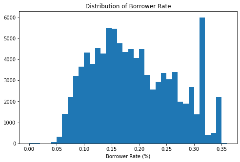

## Distribution of Loan Amount

> At first glance at the loan amount, it seemed as if it was positively skewed but after log-scaling the loan amount and taking a second look, it became clearer that theres no skewness but at some certain points, the number of loans for loan amounts seemed to increase suddenly and dropped as fast as they increased.

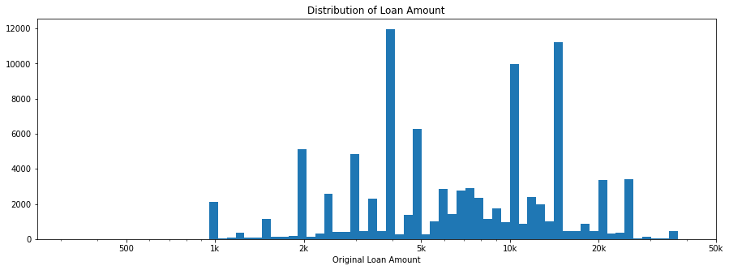

## Correlation between selected ('DebtToIncomeRatio', 'TotalProsperLoans', 'TotalProsperPaymentsBilled', 'CurrentDelinquencies', 'EmploymentStatusDuration', 'CreditScoreRangeUpper', 'CreditScoreRangeLower', 'ProsperScore', 'StatedMonthlyIncome', 'BorrowerRate', 'LoanOriginalAmount') numeric features

> For other features, a strong positive correlation was found between these features: TotalProsperLoans and TotalProsperPaymentsBilled ProsperScore and CreditScoreRangeUpper ProsperScore and CreditScoreRangeLower

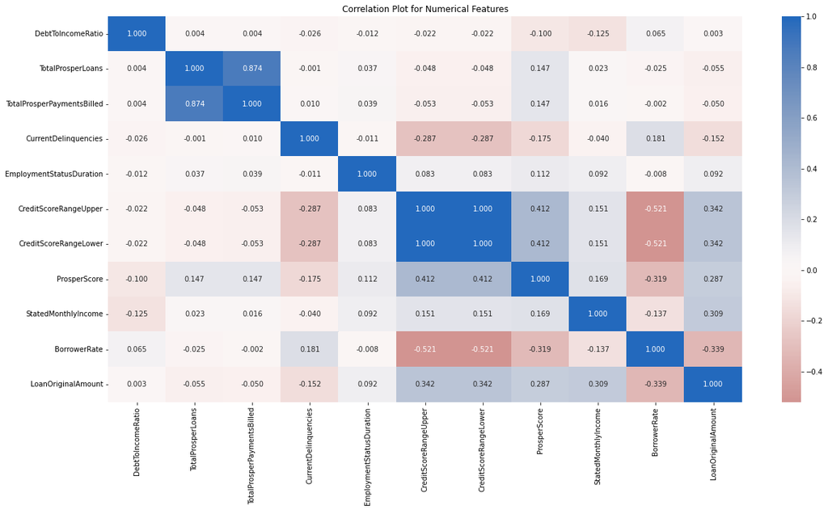

## Borrow Rate by Credit Score Range Upper by Credit Score Range Lower

> There is an interaction between Borrow Rate, Credit Score Range Upper and Credit Score Range Lower. With an increase in credit score range, both upper and lower, there is a decrease in the borrower rate i.e since borrowers with higher credit scores are more likely to repay their debts on time, then their borrower rate definitely decreases.

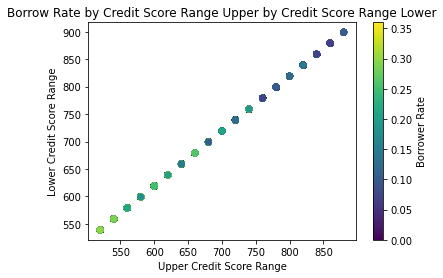

## Loan amount vs Monthly income vs Prosper score

> There is an approximate relationship between loan amount, monthly income and prosper score. A scatter plot was used to check this and the visualization confirmed that borrowers with high prosper scores are on the top right. They generally have higher monthly income and larger loan amounts. At first glance, the relationship wasn't so obvious but then after log-scaling Loan amount and Monthly income, the relationship became more obvious

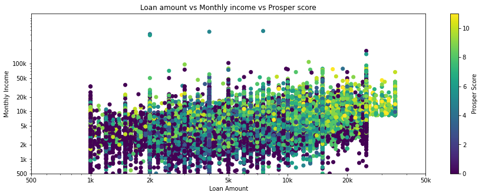

## The Loan Status vs Borrower Rate vs Employment Status

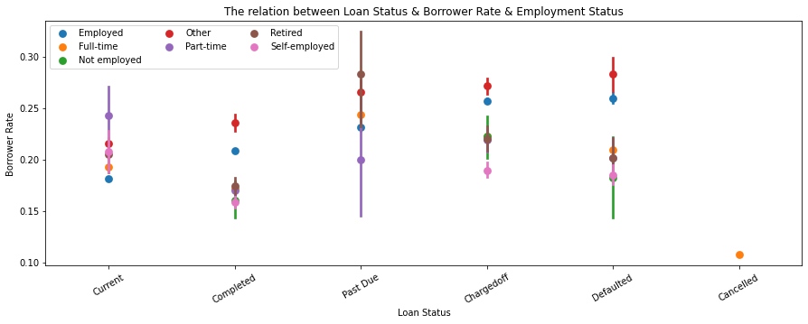

## Status of Loan vs Loan Amount vs Income Range

> There is a good correlation between Income Range and Loan Amount, the higher the income range, the higher the loan amount the borrowers were likely to take. Also, for the income range's distribution across loan amount was the same and didn't change across all loan status.

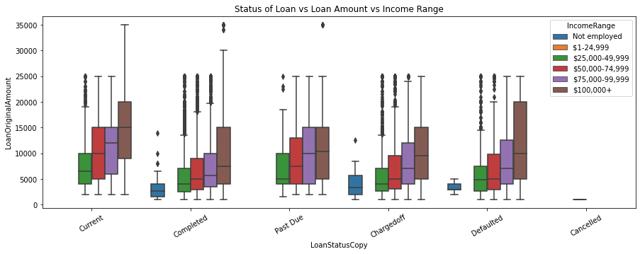